# Danielson Regression

```r
library(tidyverse)
library(arrow)
library(ResourceSelection)
library(ggpubr)
library(pander)

all <- read_parquet("../../Scripts/All_teacher_info.parquet") %>%
  filter(!is.na(Danielson_492) & gradType %in% c('Grad:Teacher')) %>%
  filter(FirstSemAge<31) %>%
  mutate(minorGroups = case_when(
    lastMinor %in% c('Earth Science Education','Physical Science Ed','Physics Education','Mathematics Education','Biology Education','Chemistry Education','Natural Science Educ','Health Education')~'STEM Minor',
    lastMinor %in% c('American Gov Education','Geography Education','Art Education','Theatre Education','Middle School General Sc')~'SocSci Minor',
    lastMinor %in% c('French Education','Spanish Education','Teach Eng Second Lang')~'Lang Minor',
    lastMinor %in% c('English Education')~'English Minor'),
  Gender = ifelse(isMale==0,'Female','Male')
)
```

```r
numerics <- all %>% select(where(is.numeric) & !contains('Danielson'))
col_means <- colMeans(numerics, na.rm = TRUE)
for (col in seq_along(numerics)) {
  numerics[[col]][is.na(numerics[[col]])] <- col_means[col]
}

colnames(numerics) <- paste0(colnames(numerics), "_no_na")

data <- cbind(numerics,all)
```

## Danielson

This analysis builds off the aggregation of Danielson observations recorded in [this article](https://sites.google.com/view/benjamin-pacini/dissertation/data-overview/danielson-fft?authuser=0).  
In summary, we’ve condensed down the Danielson observations across dozens of classes and individual reports based on three criteria:

1. For this analysis, we’ve kept *only* the students with Danielson observations for their ED 492 class, to maximize comparability across students.
2. If a student has more than one observation recorded for the class, we prioritize the summative evaluations over the formative ones.
3. To compensate for different grading standards across teachers, we’ve turned each raw final score (a 3-pt scale of 22 questions) into a z_score. Now each score reflects how the student did in this class compared to their peers.-

$$zscore = \frac{x_{StudentScore} - \mu_{TeacherAndSemester}}{\sigma_{TeacherAndSemester}}$$

After these steps, we go from 9854 individual observations to 779 unique student records.

```r
all %>%
  select(Danielson_492,FinalCumGPA,ACTSAT_Scores,isMale,
         ReceivedPell,BinaryEthnicity, NumSem, YearStarted) %>%
  head(5) %>%
  pander()
```

Table continues below

| Danielson_492 | FinalCumGPA | ACTSAT_Scores | isMale | ReceivedPell |
| --- | --- | --- | --- | --- |
| 68.12 | 4 | NA | 0 | 0 |
| 76.82 | 3.9 | NA | 0 | 1 |
| 80.21 | 3.7 | NA | 1 | 1 |
| 43.21 | 4 | 31 | 0 | 1 |
| 65.84 | 4 | 25 | 0 | 0 |

| BinaryEthnicity | NumSem | YearStarted |
| --- | --- | --- |
| White | 7 | 21 |
| White | 8 | 20 |
| White | 8 | 20 |
| Not White | 7 | 21 |
| White | 5 | 20 |

It’s important to notice that because we made all these adjustments from the raw observations, this analysis won’t be useful for predicting individual scores. This can only tell which other metrics are most likely to help students succeed.

### Danielson against GPA

```r
lm_dan_gpa <- lm(Danielson_492 ~ FinalCumGPA, data = all)
summary(lm_dan_gpa) %>% pander::pander()
```

|  | Estimate | Std. Error | t value | Pr(>\|t\|) |
| --- | --- | --- | --- | --- |
| **(Intercept)** | 15.82 | 8.174 | 1.935 | 0.0533 |
| **FinalCumGPA** | 10.87 | 2.301 | 4.723 | 2.752e-06 |

Fitting linear model: Danielson_492 ~ FinalCumGPA

| Observations | Residual Std. Error | $R^2$ | Adjusted $R^2$ |
| --- | --- | --- | --- |
| 779 | 25.56 | 0.02791 | 0.02666 |

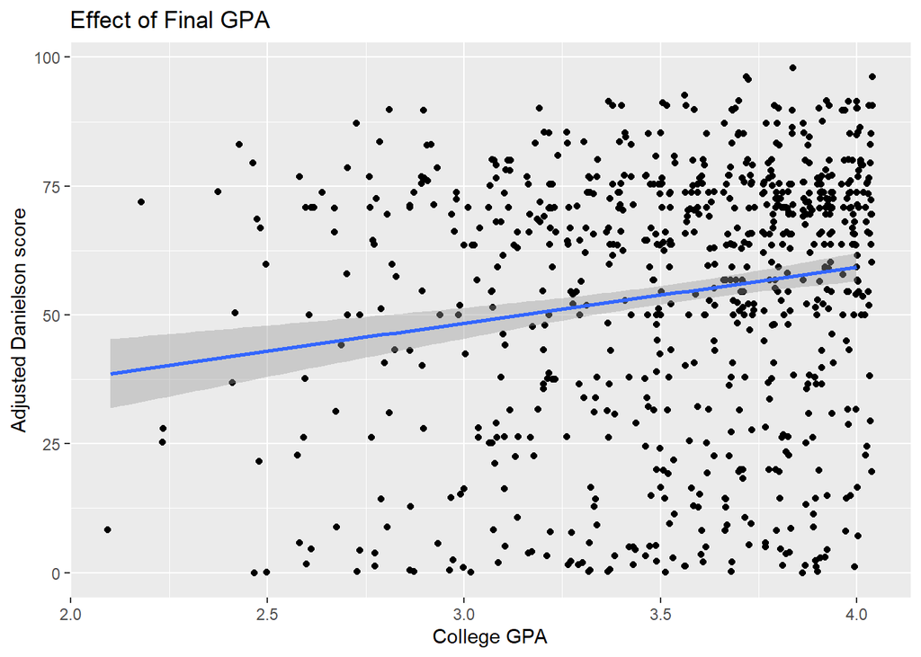

```r
ggplot(all,aes(x=FinalCumGPA,y=Danielson_492)) +
  geom_jitter() +
  geom_smooth(method = 'lm') +
  labs(x='College GPA',y='Adjusted Danielson score',
    title="Effect of Final GPA")
```

### Danielson against HS Exam Scores

Students reported their high school exam score. The SAT and ACT score on different scales, so we’ve standardized them on a 1-36 scale.

```r
lm_dan_act <- lm(Danielson_492 ~ ACTSAT_Scores, data = all)
summary(lm_dan_act) %>% pander::pander()
```

|  | Estimate | Std. Error | t value | Pr(>\|t\|) |
| --- | --- | --- | --- | --- |
| **(Intercept)** | 35.88 | 6.341 | 5.659 | 2.296e-08 |
| **ACTSAT_Scores** | 0.8415 | 0.2728 | 3.085 | 0.002123 |

Fitting linear model: Danielson_492 ~ ACTSAT_Scores

| Observations | Residual Std. Error | $R^2$ | Adjusted $R^2$ |
| --- | --- | --- | --- |
| 642 | 25.33 | 0.01465 | 0.01311 |

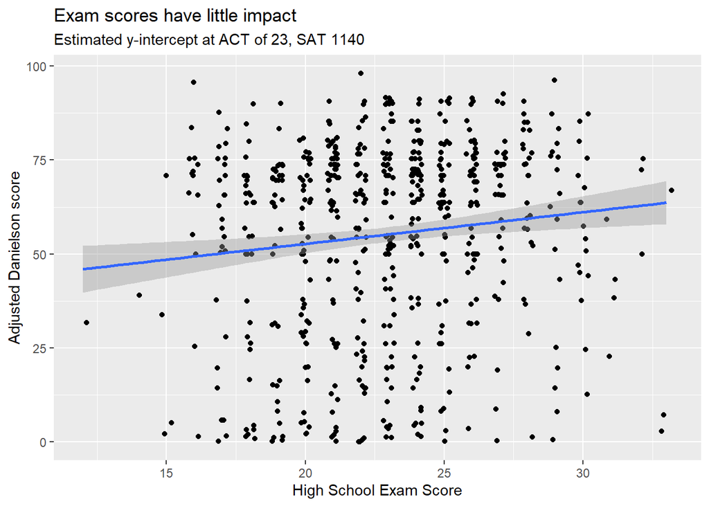

```r
ggplot(all,aes(x=ACTSAT_Scores,y=Danielson_492)) +
  geom_jitter(width = .2) +
  geom_smooth(method = 'lm') +
  labs(x='High School Exam Score',y='Adjusted Danielson score',
    title="Exam scores have little impact",
    subtitle='Estimated y-intercept at ACT of 23, SAT 1140')
```

### Danielson against Gender

```r
lm_dan_act <- lm(Danielson_492 ~ isMale, data = all)
summary(lm_dan_act) %>% pander::pander()
```

|  | Estimate | Std. Error | t value | Pr(>\|t\|) |
| --- | --- | --- | --- | --- |
| **(Intercept)** | 55.13 | 1.01 | 54.59 | 4.227e-268 |
| **isMale** | -5.911 | 2.521 | -2.344 | 0.01932 |

Fitting linear model: Danielson_492 ~ isMale

| Observations | Residual Std. Error | $R^2$ | Adjusted $R^2$ |
| --- | --- | --- | --- |
| 779 | 25.83 | 0.007023 | 0.005745 |

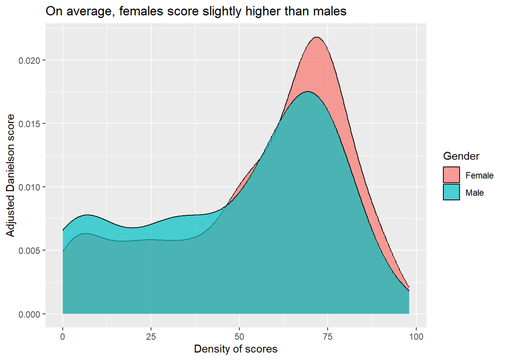

```r
ggplot(all,aes(Danielson_492,group=Gender,fill=Gender)) +
  geom_density(alpha=.7) +
  labs(x='Density of scores',y='Adjusted Danielson score',
    title="On average, females score slightly higher than males")
```

### Danielson against Pell Grant reception

We again see that it doesn’t seem to matter whether or not students receive a Pell Grant during their schooling.

```r
all$Pell <- ifelse(all$ReceivedPell==0,'Did Not Receive','Received')
lm_dan_pell <- lm(Danielson_492 ~ Pell,data=all)
summary(lm_dan_pell) %>% pander::pander()
```

|  | Estimate | Std. Error | t value | Pr(>\|t\|) |
| --- | --- | --- | --- | --- |
| **(Intercept)** | 52.87 | 1.676 | 31.55 | 2.63e-141 |
| **PellReceived** | 1.888 | 2.013 | 0.9379 | 0.3486 |

Fitting linear model: Danielson_492 ~ Pell

| Observations | Residual Std. Error | $R^2$ | Adjusted $R^2$ |
| --- | --- | --- | --- |
| 779 | 25.91 | 0.001131 | -0.0001546 |

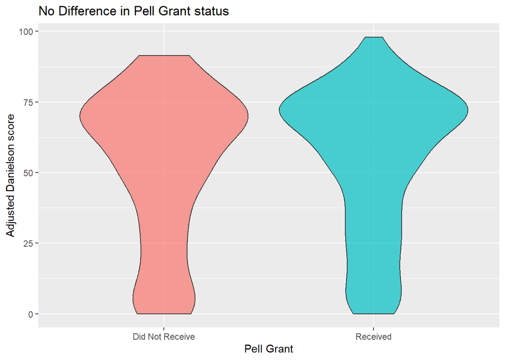

```r
ggplot(all,aes(y=Danielson_492,x=Pell,group=Pell,fill=Pell)) +
  geom_violin(alpha=.7) +
  labs(x='Pell Grant',y='Adjusted Danielson score',
    title="No Difference in Pell Grant status")  +
  theme(legend.position = 'none')
```

## Danielson against Ethnicity

To balance out the differences in enrollment among different ethnic groups, we’ve grouped together all whites and non-whites:

```r
pander(table(all$Ethnicity))
```

Table continues below

| American Indian/Alaskan | Asian | Black | Hawaiian, Pacific Island |
| --- | --- | --- | --- |
| 2 | 14 | 4 | 2 |

| Hispanic, Latino | Other | Two or More Ethnicities | Unknown | White |
| --- | --- | --- | --- | --- |
| 52 | 8 | 12 | 9 | 676 |

We find a near-zero difference between these two created categories.

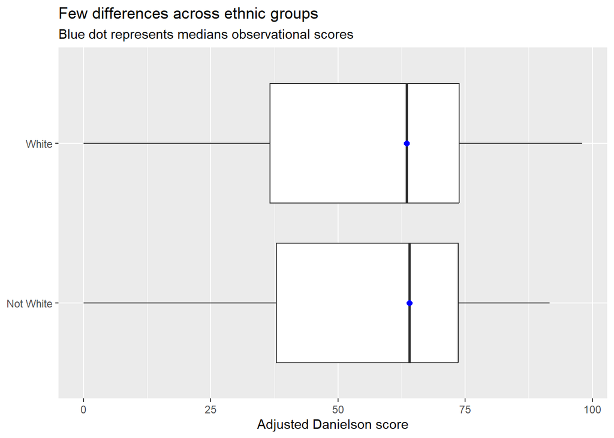

```r
ggplot(all,aes(x=BinaryEthnicity,y=Danielson_492)) +
  geom_boxplot() +
  #geom_smooth(method = 'lm') +
  geom_point(stat = "summary",
    fun = "median",
    color='blue',size=2) +
  labs(x='Ethnicity',y='Adjusted Danielson score',
    title="Few differences across ethnic groups",
    subtitle='Blue dot represents medians observational scores') +
  coord_flip() +
  theme(axis.title.y = element_blank())
```

## Danielson against Disposition

These two features have a strong positive relationship. Many of these students were tested by the same teacher for both types of evaluation, so the correlation may be influenced by the same source.

We have a number of different ways to measure Disposition scores, because they’re given in a variety of classes on a variety of metrics.

- The 200-, 300- or 400-level courses independently, for tracking progression through the their teaching development.
- The last class they took.
- A score re-weighted based on the z-score of the teacher’s students.

```r
lm_dan_disp <- lm(Danielson_492 ~  Disposition_avg+Disposition_highest_level+  Disposition_300+Disposition_400+ Disposition_200+Disposition_highest_level, data = all)
summary(lm_dan_disp) %>% pander::pander()
```

|  | Estimate | Std. Error | t value | Pr(>\|t\|) |
| --- | --- | --- | --- | --- |
| **(Intercept)** | 52.48 | 1.33 | 39.47 | 4.886e-135 |
| **Disposition_avg** | 7.396 | 5.911 | 1.251 | 0.2117 |
| **Disposition_highest_level** | 7.478 | 1.931 | 3.873 | 0.0001271 |
| **Disposition_300** | 0.02839 | 4.197 | 0.006765 | 0.9946 |
| **Disposition_400** | 0.4913 | 2.934 | 0.1675 | 0.8671 |
| **Disposition_200** | 0.9825 | 2.258 | 0.4352 | 0.6637 |

Fitting linear model: Danielson_492 ~ Disposition_avg + Disposition_highest_level + Disposition_300 + Disposition_400 + Disposition_200 + Disposition_highest_level

| Observations | Residual Std. Error | $R^2$ | Adjusted $R^2$ |
| --- | --- | --- | --- |
| 378 | 23.2 | 0.147 | 0.1355 |

Of all the different variations, the measure built on the last class the student takes is the most effective.

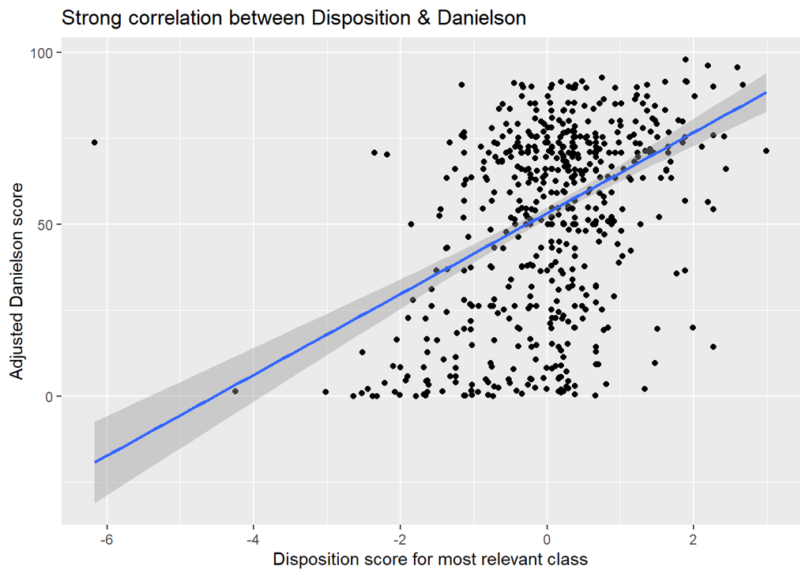

```r
ggplot(all,aes(x=Disposition_highest_level,y=Danielson_492)) +
  geom_jitter() +
  geom_smooth(method = lm) + #, formula=y ~ poly(x, 3)
  labs(x='Disposition score for most relevant class',y='Adjusted Danielson score',
    title="Strong correlation between Disposition & Danielson")
```

## All Demographic Factors

```r
demographicslm <- lm(Danielson_492~BinaryEthnicity+ReceivedPell+Gender+FirstSemAge+FirstSemMaritalStatus,data=all)
demographicslm %>%pander()
```

Fitting linear model: Danielson_492 ~ BinaryEthnicity + ReceivedPell + Gender + FirstSemAge + FirstSemMaritalStatus

|  | Estimate | Std. Error | t value | Pr(>\|t\|) |
| --- | --- | --- | --- | --- |
| **(Intercept)** | 88.46 | 14.45 | 6.123 | 1.457e-09 |
| **BinaryEthnicityWhite** | -2.174 | 2.771 | -0.7846 | 0.4329 |
| **ReceivedPell** | 2.835 | 2.036 | 1.392 | 0.1643 |
| **GenderMale** | -4.42 | 2.873 | -1.538 | 0.1244 |
| **FirstSemAge** | -1.095 | 0.6004 | -1.823 | 0.06862 |
| **FirstSemMaritalStatusSingle** | -12.77 | 5.389 | -2.37 | 0.01802 |

```r
coef <- demographicslm$coefficients
```

[figure not shown]

```r
ggplot(all,aes(x=FirstSemAge,y=Danielson_492)) +
  geom_point() + xlim(c(18,30)) +
  #Most common
  geom_abline(intercept=coef[[1]]+coef[[2]]+coef[[6]],slope=coef[[5]],color='black',linewidth=2) +
  #Difference for Males
  geom_abline(intercept=coef[[1]]+coef[[4]]+coef[[6]],slope=coef[[5]],color='green') + #Difference for Non-Whites
  geom_abline(intercept=coef[[1]]+coef[[2]]+coef[[4]]+coef[[6]],slope=coef[[5]],color='blue') + #Difference for Married
  geom_abline(intercept=coef[[1]]+coef[[2]],slope=coef[[5]],color='red') + #Difference for Pell
  geom_abline(intercept=coef[[1]]+coef[[2]]+coef[[3]]+coef[[6]],slope=coef[[5]],color='purple') +
  labs(x='Age of First Semester',y='Danielson 492 percentile',
       title='Comparing each demographic factor against the most common baseline',
       subtitle='Black is baseline, Green is change for males, Blue for non-whites, Red for married, Purple for Pell recipients') +
  theme_bw()
```

## All Pre-College Factors

```r
summary(lm(Danielson_492~ACTSAT_Scores+HighSchoolGPA+YearStarted,data=all)) %>%pander()
```

|  | Estimate | Std. Error | t value | Pr(>\|t\|) |
| --- | --- | --- | --- | --- |
| **(Intercept)** | 20.44 | 10.61 | 1.926 | 0.05459 |
| **ACTSAT_Scores** | 0.7189 | 0.3173 | 2.266 | 0.02385 |
| **HighSchoolGPA** | 3.899 | 3.107 | 1.255 | 0.21 |
| **YearStarted16** | 3.283 | 3.708 | 0.8854 | 0.3763 |
| **YearStarted17** | 6.602 | 3.478 | 1.898 | 0.05814 |
| **YearStarted18** | 5.835 | 3.657 | 1.596 | 0.1111 |
| **YearStarted19** | 4.221 | 4.093 | 1.031 | 0.3028 |
| **YearStarted20** | -2.208 | 7.871 | -0.2805 | 0.7792 |
| **YearStarted21** | -6.806 | 25.54 | -0.2665 | 0.79 |

Fitting linear model: Danielson_492 ~ ACTSAT_Scores + HighSchoolGPA + YearStarted

| Observations | Residual Std. Error | $R^2$ | Adjusted $R^2$ |
| --- | --- | --- | --- |
| 591 | 25.28 | 0.02857 | 0.01522 |

## All In-College Factors

I’ve divided the graduating student’s minors into these categories:

- Earth Science Education, Physical Science Ed, Physics Education, Mathematics Education, Biology Education, Chemistry Education, Natural Science Educ, Health Education = STEM Minor
- American Gov Education, Geography Education, Art Education, Theatre Education, Middle School General Sc = SocSci Minor
- French Education, Spanish Education, Teach Eng Second Lang = Lang Minor
- Other minors were popular enough to keep as their own category.

```r
summary(lm(Danielson_492~Disposition_highest_level+Disposition_200+NumSem+NumSemSenior+PercentOfSemAsTeacher+FirstSemGPAinTeaching+FinalCumGPA + FirstSemAge+NumSemTakingClasses+minorGroups+DegreeType,data=all))%>%pander()
```

|  | Estimate | Std. Error | t value | Pr(>\|t\|) |
| --- | --- | --- | --- | --- |
| **(Intercept)** | 83.97 | 34.12 | 2.461 | 0.01465 |
| **Disposition_highest_level** | 10.34 | 1.921 | 5.383 | 1.908e-07 |
| **Disposition_200** | 3.832 | 2.452 | 1.562 | 0.1197 |
| **NumSem** | -0.03279 | 0.9706 | -0.03378 | 0.9731 |
| **NumSemSenior** | -0.5372 | 1.008 | -0.5331 | 0.5945 |
| **PercentOfSemAsTeacher** | -7.567 | 11.42 | -0.6626 | 0.5083 |
| **FirstSemGPAinTeaching** | 3.56 | 3.845 | 0.9258 | 0.3556 |
| **FinalCumGPA** | -5.069 | 5.687 | -0.8912 | 0.3738 |
| **FirstSemAge** | -0.8826 | 0.931 | -0.948 | 0.3442 |
| **NumSemTakingClasses** | -0.3081 | 1.385 | -0.2224 | 0.8242 |
| **minorGroupsLang Minor** | 4.791 | 4.572 | 1.048 | 0.2959 |
| **minorGroupsSocSci Minor** | 0.5589 | 5.914 | 0.09451 | 0.9248 |
| **minorGroupsSTEM Minor** | 6.876 | 4.79 | 1.436 | 0.1526 |
| **DegreeTypeSecondary** | -2.957 | 3.834 | -0.7715 | 0.4413 |

Fitting linear model: Danielson_492 ~ Disposition_highest_level + Disposition_200 + NumSem + NumSemSenior + PercentOfSemAsTeacher + FirstSemGPAinTeaching + FinalCumGPA + FirstSemAge + NumSemTakingClasses + minorGroups + DegreeType

| Observations | Residual Std. Error | $R^2$ | Adjusted $R^2$ |
| --- | --- | --- | --- |
| 229 | 23.57 | 0.1871 | 0.138 |

## All Significant Factors

We’ve filled in the missing values with the averages for each of these factors, so this model includes all 779 students.

```r
lm(Danielson_492~Disposition_highest_level_no_na+FirstSemMaritalStatus+YearStarted+BinaryEthnicity+Gender+ACTSAT_Scores_no_na+FirstSemAge_no_na+FinalCumGPA_no_na,data=data) %>% summary() %>% pander()
```

|  | Estimate | Std. Error | t value | Pr(>\|t\|) |
| --- | --- | --- | --- | --- |
| **(Intercept)** | 59.22 | 17.24 | 3.435 | 0.0006255 |
| **Disposition_highest_level_no_na** | 11.25 | 0.9954 | 11.3 | 1.679e-27 |
| **FirstSemMaritalStatusSingle** | -7.64 | 5.036 | -1.517 | 0.1296 |
| **YearStarted16** | 1.728 | 3.165 | 0.5459 | 0.5853 |
| **YearStarted17** | 3.392 | 2.991 | 1.134 | 0.2572 |
| **YearStarted18** | 2.401 | 3.126 | 0.7682 | 0.4426 |
| **YearStarted19** | 2.048 | 3.431 | 0.5969 | 0.5507 |
| **YearStarted20** | -3.769 | 5.257 | -0.7169 | 0.4737 |
| **YearStarted21** | 5.005 | 12.29 | 0.4074 | 0.6839 |
| **BinaryEthnicityWhite** | -3.076 | 2.569 | -1.197 | 0.2315 |
| **GenderMale** | -3.846 | 2.681 | -1.435 | 0.1518 |
| **ACTSAT_Scores_no_na** | 0.4894 | 0.2687 | 1.821 | 0.06894 |
| **FirstSemAge_no_na** | -0.6312 | 0.5728 | -1.102 | 0.2709 |
| **FinalCumGPA_no_na** | 1.023 | 2.414 | 0.4238 | 0.6718 |

Fitting linear model: Danielson_492 ~ Disposition_highest_level_no_na + FirstSemMaritalStatus + YearStarted + BinaryEthnicity + Gender + ACTSAT_Scores_no_na + FirstSemAge_no_na + FinalCumGPA_no_na

| Observations | Residual Std. Error | $R^2$ | Adjusted $R^2$ |
| --- | --- | --- | --- |
| 779 | 23.63 | 0.1819 | 0.168 |